# Defining ‘rivers’ for the galamsey study — OSM vs MERIT Hydro vs remote sensing

An exploration on the Ankobra basin — notes and open questions

Till Meissner

02 Juli 2026

# 1 What this research project is about

*(Context for a reader coming to this cold — feel free to skip to the specific question.)*

**Galamsey** is small-scale, largely unlicensed **artisanal gold mining**, which has expanded rapidly across southern Ghana over the last two decades. Beyond clearing vegetation and reshaping valley floors, it discharges **mercury, suspended sediment and turbidity into rivers**, with widely reported consequences for water quality and for farmland downstream.

This research project **maps galamsey and studies its drivers and consequences**, in two phases:

1. **Remote sensing** — classifying mine presence from Landsat/Sentinel-2 imagery via Google Earth Engine (1995–2025, all Ghana).
2. **Spatial & economic analysis** — where mining occurs, why it clusters spatially, and what it does to the surrounding environment and economy.

The current analysis uses the **Barenblitt et al. (2021)** satellite-derived mining-extent maps for **SW Ghana** (annual, 2007–2017) as an interim data source, on a **hexagonal grid** (~5 km cells) over the study region — see §Why hexagons below for why that unit was chosen.

**The specific piece this note supports** is an *event study* of the **downstream** effect of mining: does galamsey **upstream** of a location degrade vegetation — and, by proxy, agricultural productivity and water quality — **downstream**, through waterborne transport of mercury and sediment? We proxy the downstream outcome with satellite **vegetation greenness (NDVI)**. To run that design we must know, for every location, which mines are hydrologically **upstream** of it. That is entirely a question of **how we define the river network and its direction of flow** — which is what this note is about, and where we would most value a geologist’s / hydrologist’s input.

# 2 The question we are unsure about

This is a working note, not a settled write-up — we would value a geologist’s / hydrologist’s view on whether we are framing the problem sensibly at all.

“River” enters the analysis in **two different places**, and it is not obvious the same definition should serve both:

1. **A proximity covariate — `dist_river_km`.** Distance to the nearest watercourse as a predictor of *where* galamsey occurs. Here we need channel geometry.
2. **A directed flow graph — the event-study treatment.** The upstream→downstream design needs channels **and flow direction**, respecting drainage divides.

| Source | What a “river” is | Flow direction? | Small tributaries? |
| --- | --- | --- | --- |
| **OSM waterways** | A line a human mapped and labelled | No | Patchy — depends on mapping effort |
| **MERIT Hydro** | A DEM cell whose upstream drainage area exceeds a threshold | **Yes** (D8) | Yes, down to the chosen threshold |
| **Remote sensing** (MNDWI / JRC) | A pixel observed to hold surface water | No | Only where water is visible |

> **The worry that motivates this note.** Does the pollution signal from *large* rivers get diluted if we also label as “treated” many hexes that sit only on *tiny streams* — which may not actually transport mercury/sediment far? But if we raise the threshold to keep only large channels, a large share of mining hexes fall out of the sample. **Is that the right way to think about the trade-off, and how should it be handled?** See *The event-study trade-off*.

We work on the **Ankobra basin** — the SW-Ghana river most associated with galamsey pollution, and the area for which we already have a MERIT clip.

# 3 Study area — the Ankobra corridor

```r
# MERIT clip = the analysis window (the Ankobra corridor, native EPSG:4326).
hydro <- rast(merit_path)
names(hydro) <- c("dir", "upa", "wth", "elv")
dir_r <- hydro[["dir"]]; upa_r <- hydro[["upa"]]; wth_r <- hydro[["wth"]]; elv_r <- hydro[["elv"]]
wth_ch <- wth_r; wth_ch[wth_ch == 0] <- NA
wth_pos <- values(wth_r, na.rm = TRUE); wth_pos <- wth_pos[wth_pos > 0]

merit_ext_ll  <- st_as_sf(as.polygons(ext(upa_r), crs = "EPSG:4326"))
merit_ext_utm <- st_transform(merit_ext_ll, UTM30N)

osm <- st_read(osm_path, quiet = TRUE) |> clean_names() |> st_make_valid() |>
  st_transform(4326)
osm_win <- suppressWarnings(st_crop(osm, st_bbox(merit_ext_ll)))

gal <- st_read(barenblitt_path, quiet = TRUE) |> clean_names() |> st_make_valid() |>
  st_transform(4326)
mt_col <- intersect(c("mine_type", "minetype"), names(gal))[1]
gal_win <- suppressWarnings(st_crop(gal[gal[[mt_col]] == 1, ], st_bbox(merit_ext_ll)))

cat(sprintf("MERIT window: %.2f x %.2f deg | %d OSM segments | %d galamsey polygons\n",
            diff(st_bbox(merit_ext_ll)[c(1,3)]), diff(st_bbox(merit_ext_ll)[c(2,4)]),
            nrow(osm_win), nrow(gal_win)))
```

```
## MERIT window: 0.35 x 1.01 deg | 45 OSM segments | 1540 galamsey polygons
```

# 4 Approach 1 — OSM waterways

OpenStreetMap `waterway=*` lines are crowd-sourced, human-labelled. They give real, named rivers and a type field we can filter on. `d_03_waterways.R` keeps only *natural* watercourses; artificial canals/drains/ditches presumably cannot host alluvial gold (a safe assumption? — one for discussion).

```r
natural    <- c("river", "stream", "brook", "wadi", "tidal_channel", "stream_pool", "flowline")
artificial <- c("canal", "drain", "ditch", "lock_gate", "fish_pass", "weir", "dam",
                "sluice_gate", "pressurised", "penstock")
osm_win <- osm_win |>
  mutate(ww_class = case_when(waterway %in% natural ~ "natural watercourse",
                              waterway %in% artificial ~ "artificial channel",
                              TRUE ~ "other / review"))

osm_win |> st_drop_geometry() |> count(waterway, ww_class, sort = TRUE) |>
  knitr::kable(caption = "OSM waterway types within the Ankobra window.")
```

OSM waterway types within the Ankobra window.

| waterway | ww_class | n |
| --- | --- | --- |
| river | natural watercourse | 20 |
| stream | natural watercourse | 18 |
| drain | artificial channel | 7 |

Coverage seems to be a function of *mapping effort* rather than hydrology — small tributaries (where alluvial galamsey may begin) look unevenly mapped, and there is no flow direction. It may be fine as *a* proximity measure; it cannot build the directed flow graph. (See the combined map in §Channel network below for OSM alongside MERIT and galamsey.)

# 5 Approach 2 — MERIT Hydro

MERIT Hydro (Yamazaki et al. 2019, ~90 m) is a DEM-derived, physically-modelled river network, with four bands used differently in this project:

| Band | Meaning | Use |
| --- | --- | --- |
| `dir` | D8 flow direction (which neighbour each cell drains to) | The flow graph (upstream/downstream) |
| `upa` | Upstream drainage area (km²) accumulated through each cell | Defining channels via a threshold |
| `wth` | Satellite/OSM-fused river **width** (m); 0 = no mapped channel | A stricter, validated channel mask |
| `elv` | Hydrologically-adjusted elevation | HAND / vertical drop (not morphometry) |

## 5.1 Why hexagons, and how the build pipeline turns MERIT into a hex flow graph

**Why hexagons.** The whole project (not just this note) uses a ~5 km hexagonal grid as its unit of analysis, generated once in `b_01_cross_section.R` and re-used everywhere downstream (`hex_id` is the join key across every script). Three reasons hexagons rather than a square/raster grid:

- **Uniform adjacency.** Every hex has exactly 6 neighbours, all at the *same* centre-to-centre distance. A square grid’s 4 edge-neighbours are closer than its 4 diagonal neighbours — that asymmetry distorts “queen contiguity” spatial weights (used for Moran’s I / the spatial-lag model in `a_02`) and would make “1-hop neighbour” an ambiguous idea for the event study.
- **Compact shape.** A hexagon approximates a circle better than a square, reducing edge artefacts when averaging NDVI/EVI or mining area within a cell (zonal statistics).
- **No orientation bias**, unlike a north-aligned square grid, when the underlying drainage pattern has no reason to align with cardinal directions.

**How `d_04_merit.R` builds the hex-to-hex flow graph (Sec 11a–11c).** MERIT’s `dir`/`upa` are native ~90 m *raster* cells — far finer than a 5 km hex — so the pipeline has to collapse cell-level flow into hex-level edges:

1. **Rasterise the hex grid onto the MERIT grid (Sec 11a).** Every ~90 m MERIT cell is tagged with the `hex_id` of the 5 km hex it falls inside (`terra::rasterize()`).
2. **Per-cell downstream lookup (Sec 11b).** For every **channel cell** (`upa > ROUTE_KM2`), its D8 `dir` code gives a fixed row/column offset to its single downstream neighbour cell (e.g. code 4 = south = `+1` row). That neighbour cell inherits its own `hex_id` from step 1.
3. **Collapse to hex-to-hex edges (Sec 11c).** Whenever a channel cell’s downstream neighbour sits in a *different* hex, that is a candidate `hex_A → hex_B` edge. All such crossings between the same pair of hexes are aggregated and **netted to one dominant direction**, weighted by flow magnitude (`upa`) — this cleans up D8 noise near hex boundaries, where a meander can otherwise produce edges in both directions.
4. **Force a DAG.** Any residual cycles (rare; benign meander/aggregation artefacts once step 3’s direction-netting is applied) are broken via a feedback-arc-set algorithm, so “everything upstream of hex X” is a well-defined graph query.

The figure below walks through the same four steps on a small **synthetic** two-hex example (no real data — a schematic, like the neighbour-role diagram in `a_05_event_study.Rmd`):

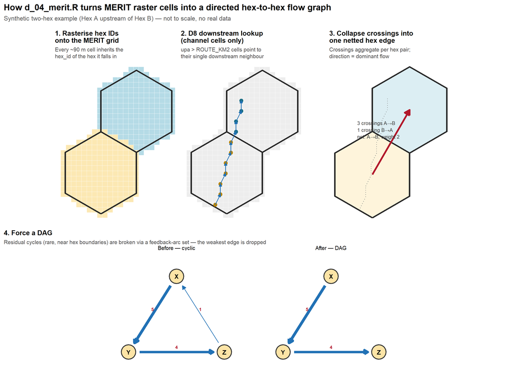

```r
# Synthetic two-hex example illustrating d_04_merit.R Sec 11a-11c. Not to scale, no real data --
# purely a teaching schematic (mirrors the synthetic schematic in a_05_event_study.Rmd).

# ---- shared base: two adjacent hexes + a fine "MERIT cell" grid over them ----
bbox_sfc <- st_as_sfc(st_bbox(c(xmin = 0, ymin = 0, xmax = 6000, ymax = 3200)))
st_crs(bbox_sfc) <- UTM30N
hex_all <- st_sf(geometry = st_make_grid(bbox_sfc, cellsize = 3000, square = FALSE)) |>
  mutate(hid = row_number())
hex_ab <- hex_all[hex_all$hid %in% c(2, 3), ] |>
  mutate(hex_id = c("Hex A", "Hex B")[match(hid, c(2, 3))])

cell_bbox <- st_as_sfc(st_bbox(c(xmin = -1700, ymin = -1900, xmax = 3200, ymax = 4500)))
st_crs(cell_bbox) <- UTM30N
cells <- st_sf(geometry = st_make_grid(cell_bbox, cellsize = 220, square = TRUE)) |>
  mutate(cx = st_coordinates(st_centroid(geometry))[, 1],
         cy = st_coordinates(st_centroid(geometry))[, 2])
inA <- lengths(st_intersects(cells, hex_ab[hex_ab$hex_id == "Hex A", ])) > 0
inB <- lengths(st_intersects(cells, hex_ab[hex_ab$hex_id == "Hex B", ])) > 0
cells <- cells[inA | inB, ] |> mutate(hex_id = ifelse(inA[inA | inB], "Hex A", "Hex B"))
hex_cols <- c("Hex A" = "#FCE4A6", "Hex B" = "#A8D5E2")

# A "channel" snaking from Hex A into Hex B, snapped onto the fine cell grid.
bez <- function(t, p0, pc, p2) (1 - t)^2 * p0 + 2 * (1 - t) * t * pc + t^2 * p2
tt <- seq(0, 1, length.out = 11)
path_xy <- t(sapply(tt, \(t) bez(t, c(-500, -1300), c(250, 950), c(650, 3000))))
snap_idx <- unique(sapply(seq_len(nrow(path_xy)),
                          \(i) which.min((cells$cx - path_xy[i, 1])^2 + (cells$cy - path_xy[i, 2])^2)))
chan <- cells[snap_idx, ] |> mutate(order = seq_along(snap_idx))
arrows_df <- tibble(x = chan$cx[-nrow(chan)], y = chan$cy[-nrow(chan)],
                    xend = chan$cx[-1], yend = chan$cy[-1])

base_theme <- theme_void(base_size = 9.5) +
  theme(plot.title = element_text(face = "bold", size = 9.5),
        plot.subtitle = element_text(size = 7.6, colour = "grey30", lineheight = 1.05))

# Panel 1 — Sec 11a: rasterise hex IDs onto the MERIT grid.
p1 <- ggplot() +
  geom_sf(data = cells, aes(fill = hex_id), colour = "white", linewidth = 0.05, alpha = 0.85) +
  geom_sf(data = hex_ab, fill = NA, colour = "grey15", linewidth = 1) +
  scale_fill_manual(values = hex_cols, guide = "none") +
  labs(title = "1. Rasterise hex IDs\nonto the MERIT grid",
       subtitle = "Every ~90 m cell inherits the\nhex_id of the hex it falls in") +
  base_theme

# Panel 2 — Sec 11b: per-channel-cell D8 downstream lookup.
p2 <- ggplot() +
  geom_sf(data = cells, fill = "grey93", colour = "white", linewidth = 0.05) +
  geom_sf(data = hex_ab, fill = NA, colour = "grey15", linewidth = 1) +
  geom_point(data = chan, aes(cx, cy, colour = hex_id), size = 2.3) +
  geom_segment(data = arrows_df, aes(x = x, y = y, xend = xend, yend = yend),
               arrow = arrow(length = unit(0.14, "cm"), type = "closed"),
               colour = "#2171B5", linewidth = 0.55) +
  scale_colour_manual(values = c("Hex A" = "#B8860B", "Hex B" = "#1B6E85"), guide = "none") +
  labs(title = "2. D8 downstream lookup\n(channel cells only)",
       subtitle = "upa > ROUTE_KM2 cells point to\ntheir single downstream neighbour") +
  base_theme

# Panel 3 — Sec 11c: collapse cross-hex crossings into one netted hex-to-hex edge.
cent_a <- st_coordinates(st_centroid(hex_ab[hex_ab$hex_id == "Hex A", ]))
cent_b <- st_coordinates(st_centroid(hex_ab[hex_ab$hex_id == "Hex B", ]))
main_arrow <- tibble(x = cent_a[1, 1], y = cent_a[1, 2], xend = cent_b[1, 1], yend = cent_b[1, 2])
p3 <- ggplot() +
  geom_sf(data = hex_ab, aes(fill = hex_id), colour = "grey15", linewidth = 1, alpha = 0.4,
          show.legend = FALSE) +
  scale_fill_manual(values = hex_cols) +
  geom_path(data = chan, aes(cx, cy), colour = "grey50", linewidth = 0.4, linetype = "dotted") +
  geom_segment(data = main_arrow, aes(x = x, y = y, xend = xend, yend = yend),
               arrow = arrow(length = unit(0.28, "cm"), type = "closed"),
               colour = "#B2182B", linewidth = 1.3) +
  annotate("text", x = (cent_a[1, 1] + cent_b[1, 1]) / 2 - 1350,
           y = (cent_a[1, 2] + cent_b[1, 2]) / 2 + 500,
           label = "3 crossings A→B\n1 crossing B→A\nnet: A→B, weight 2",
           size = 2.4, colour = "grey20", hjust = 0) +
  coord_sf(clip = "off") +
  labs(title = "3. Collapse crossings into\none netted hex edge",
       subtitle = "Crossings aggregate per hex pair;\ndirection = dominant flow") +
  base_theme + theme(plot.margin = margin(2, 2, 2, 32))

# Panel 4 — DAG enforcement: a small abstract 3-hex cycle, before/after feedback-arc removal.
nodes <- tibble(hex = c("X", "Y", "Z"), x = c(0, -0.95, 0.95), y = c(1, -0.5, -0.5))
shrink_seg <- function(x, y, xend, yend, r = 0.22) {
  dx <- xend - x; dy <- yend - y; len <- sqrt(dx^2 + dy^2)
  list(x = x + dx / len * r, y = y + dy / len * r, xend = xend - dx / len * r, yend = yend - dy / len * r)
}
mk_edges <- function(df) { s <- shrink_seg(df$x, df$y, df$xend, df$yend)
  df |> mutate(x = s$x, y = s$y, xend = s$xend, yend = s$yend) }
edges_before <- tibble(from = c("X", "Y", "Z"), to = c("Y", "Z", "X"), w = c(5, 4, 1)) |>
  left_join(nodes, by = c("from" = "hex")) |>
  left_join(nodes, by = c("to" = "hex"), suffix = c("", "end")) |>
  mk_edges() |> mutate(state = "Before — cyclic")
edges_after <- edges_before |> filter(!(from == "Z" & to == "X")) |> mutate(state = "After — DAG")
edges_all <- bind_rows(edges_before, edges_after) |>
  mutate(state = factor(state, levels = c("Before — cyclic", "After — DAG")))
nodes_all <- bind_rows(mutate(nodes, state = "Before — cyclic"), mutate(nodes, state = "After — DAG")) |>
  mutate(state = factor(state, levels = levels(edges_all$state)))

p4 <- ggplot() +
  geom_segment(data = edges_all, aes(x = x, y = y, xend = xend, yend = yend, linewidth = w),
               arrow = arrow(length = unit(0.2, "cm"), type = "closed"), colour = "#2171B5") +
  geom_point(data = nodes_all, aes(x, y), size = 9, colour = "grey20", fill = "#FCE4A6",
             shape = 21, stroke = 1) +
  geom_text(data = nodes_all, aes(x, y, label = hex), fontface = "bold", size = 3) +
  geom_text(data = edges_all, aes(x = (x + xend) / 2, y = (y + yend) / 2, label = w),
            size = 2.3, colour = "#B2182B", fontface = "bold", nudge_y = 0.1) +
  scale_linewidth(range = c(0.4, 2), guide = "none") +
  facet_wrap(~state) +
  coord_equal(clip = "off", xlim = c(-1.3, 1.3), ylim = c(-0.9, 1.4)) +
  labs(title = "4. Force a DAG",
       subtitle = "Residual cycles (rare, near hex boundaries) are broken via a feedback-arc set — the weakest edge is dropped") +
  base_theme + theme(strip.text = element_text(size = 7.6), panel.spacing = unit(1, "lines"))

(p1 | p2 | p3) / p4 +
  plot_layout(heights = c(1.3, 1)) +
  plot_annotation(
    title    = "How d_04_merit.R turns MERIT raster cells into a directed hex-to-hex flow graph",
    subtitle = "Synthetic two-hex example (Hex A upstream of Hex B) — not to scale, no real data",
    theme    = theme(plot.title = element_text(face = "bold", size = 12),
                     plot.subtitle = element_text(size = 9, colour = "grey35")))
```

The result — `hex_flow_edges_5km.csv`, a directed `from_hex, to_hex` edge list — is exactly what the event study’s upstream/downstream treatment columns are built from (via `igraph` reachability in `b_03c`/`b_03d`/`b_03e`). Routing is done on the **native EPSG:4326** grid throughout, never a reprojected one: reprojecting the categorical `dir` band relocates cells and corrupts D8 routing.

## 5.2 Why a `upa` threshold defines a “river” (and where we are unsure)

`upa` is the catchment area draining through each cell (step 2 above only counts *channel* cells). Headwater cells have a tiny `upa`; moving downstream, tributaries merge and `upa` grows **monotonically**. Our reasoning: a river is *where concentrated flow persists*, so a cell is “channel” when `upa` exceeds a minimum catchment — **the threshold is the smallest upslope area we are willing to call a channel.** Low threshold → a dense network reaching every gully; high threshold → only the major trunk survives.

**But is upstream area even the right variable to threshold on?** A geologist might prefer discharge, stream order, channel width, or stream power — `upa` is a proxy for “how much water”, not a measurement of it. We would welcome a view on the physically meaningful cut-off for “this is a river that can move sediment and contaminants”.

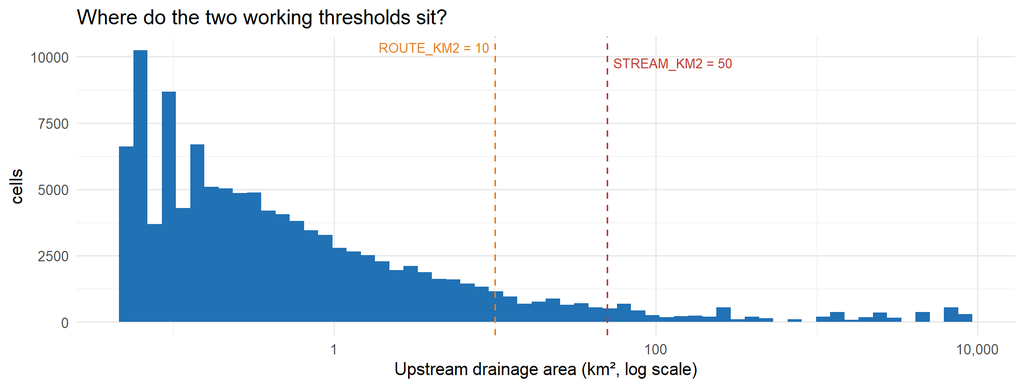

```r
upa_vals <- values(upa_r, na.rm = TRUE)
tibble(upa = upa_vals[upa_vals > 0.05]) |>
  ggplot(aes(upa)) +
  geom_histogram(bins = 60, fill = "#2171B5") +
  geom_vline(xintercept = c(10, 50), colour = c("#E67E22", "#C0392B"), linetype = 2) +
  scale_x_log10(labels = comma) +
  annotate("text", x = 10, y = Inf, label = "ROUTE_KM2 = 10", vjust = 1.5, hjust = 1.05,
           colour = "#E67E22", size = 3) +
  annotate("text", x = 50, y = Inf, label = "STREAM_KM2 = 50", vjust = 3, hjust = -0.05,
           colour = "#C0392B", size = 3) +
  labs(title = "Where do the two working thresholds sit?",
       x = "Upstream drainage area (km², log scale)", y = "cells") +
  theme_minimal(base_size = 11)
```

## 5.3 The channel network at several thresholds

```r
THRESH <- c(5, 10, 20, 50, 500)
map_dfr(THRESH, \(t) {
  n <- sum(upa_vals > t)
  tibble(`upa >` = paste0(t, " km²"), `channel cells` = n,
         `% of grid` = round(100 * n / length(upa_vals), 2))
}) |>
  knitr::kable(caption = "Channel-cell count by upa threshold. Lower cut = denser network reaching further up the tributaries.")
```

Channel-cell count by upa threshold. Lower cut = denser network reaching further up the tributaries.

| upa > | channel cells | % of grid |
| --- | --- | --- |
| 5 km² | 17008 | 3.27 |
| 10 km² | 12173 | 2.34 |
| 20 km² | 9247 | 1.78 |
| 50 km² | 6180 | 1.19 |
| 500 km² | 2686 | 0.52 |

**One consolidated map** — toggle layers to compare OSM, galamsey, and MERIT channels/width at several cuts:

```r
thr_show <- c(10, 50)   # ROUTE_KM2 vs STREAM_KM2
thr_cols <- c(col_upa10, col_upa50)
class_pal <- colorFactor(c(col_osm_nat, col_osm_art, col_osm_oth),
                         domain = c("natural watercourse", "artificial channel", "other / review"))
pal_wth <- colorNumeric("plasma", domain = wth_pos, na.color = "transparent")

m <- leaflet() |>
  addProviderTiles("Esri.WorldImagery", group = "Satellite") |>
  addProviderTiles("CartoDB.Positron",  group = "Light")
for (i in seq_along(thr_show)) {
  mask_i <- ifel(upa_r > thr_show[i], 1L, NA)
  pal_i  <- colorNumeric(thr_cols[i], domain = c(0, 1), na.color = "transparent")
  m <- addRasterImage(m, mask_i, colors = pal_i, opacity = 0.95, project = TRUE,
                      group = sprintf("MERIT upa > %g km²", thr_show[i]))
}
m |>
  addRasterImage(wth_ch, colors = pal_wth, opacity = 1, project = TRUE,
                 group = "MERIT width (wth)") |>
  addPolylines(data = osm_win, color = ~class_pal(ww_class), weight = 1.8, opacity = 0.95,
               label = ~paste0(coalesce(name, "(unnamed)"), " — ", waterway),
               group = "OSM waterways") |>
  addPolygons(data = gal_win, color = "white", weight = 1, fillColor = col_gal,
              fillOpacity = 0.6, group = "Galamsey (Barenblitt)") |>
  addLegend(pal = class_pal, values = osm_win$ww_class, title = "OSM class",
            position = "bottomright") |>
  addLayersControl(baseGroups = c("Satellite", "Light"),
                   overlayGroups = c(sprintf("MERIT upa > %g km²", thr_show), "MERIT width (wth)",
                                     "OSM waterways", "Galamsey (Barenblitt)"),
                   options = layersControlOptions(collapsed = FALSE)) |>
  hideGroup(c("MERIT upa > 50 km²", "MERIT width (wth)"))
```

[interactive chart not shown]

At `upa > 50 km²` we get the trunk Ankobra and its main tributaries, close to the OSM *natural* lines (roughly why `STREAM_KM2 = 50` was chosen). Dropping to `upa > 10 km²` fills in a finer tributary network that OSM misses and that many galamsey polygons sit on. `wth` (satellite/OSM-fused, validated channel width) marks only the confidently-mapped wider reaches — a stricter, more “physical” mask than any `upa` cut, but it misses narrow headwater tributaries. **Which of these is the “real” river network for pollution transport is exactly what we are unsure about.**

## 5.4 Why two thresholds, and the tension between them

The project uses **two** cuts for the two jobs from the introduction:

- **`STREAM_KM2 = 50`** — the “river” label; reproduces the OSM natural-river network.
- **`ROUTE_KM2 = 10`** — the flow-graph routing cut, lower so the directed graph reaches smaller tributaries. Justification (`d_04_merit.R` §11g): at `upa > 50` about **23% of mined hectares** fall off the channel network (never routed downstream), versus **~5.5% at `upa > 10`**.

A sweep over {2, 5, 10, 20} km² (`d_04` §11j) shows the per-hex upstream-exposure *ranking* is stable across cuts — so the routing/*connectivity* choice is not critical. But that robustness says nothing about *how much pollution a channel can carry*, which is the next section’s concern.

# 6 The event-study trade-off: small streams vs. sample size

In the waterborne design, a hex is (loosely) “waterborne-treated” if it connects to upstream mining via a channel. **The channel threshold sets who is in that sample, and cuts two ways:**

- **Low threshold (dense network).** Almost every mining hex counts as “on a river” — but many of those channels are tiny headwater streams with little discharge. If they don’t actually transport mercury/sediment far, we are labelling many hexes as waterborne-connected when physically they are not — **measurement error in the treatment**, which typically **attenuates** the estimated effect (the genuine large-river signal gets averaged with false-positive “treated” hexes).
- **High threshold (sparse network).** Remaining channels are genuinely big rivers, so “treated” is more plausibly real — but a large share of mining hexes **drop out** of the sample. That costs power, and may also **change which mines are in the sample** (mines on big rivers may differ systematically from mines on small streams), so it’s a possible selection/composition change too.

**Is this the right framing?** The trade-off looks real, but “pick one threshold” may not be the right response: **(1)** the threshold conflates *connectivity* (is the hex linked to a mine at all?) with *dose* (how much contaminant could arrive?) — one binary cut is being asked to do both jobs; and **(2)** transport capacity is presumably continuous, not a step at 10 or 50 km².

## 6.1 How many mining hexes are “at a river” at each threshold?

For 5 km hexes in the Ankobra window, we flag mining hexes (Barenblitt artisanal, `art_ha > 0`) and ask, per definition, whether the hex counts as “on a river” at all — for MERIT, whether it contains a channel cell above the given `upa` cut; for OSM, whether it directly intersects a mapped natural watercourse. Either way this is the source side of the waterborne channel: a mine only injects pollution into the network if its own hex is “on” whichever network we choose.

```r
cs <- readRDS(hex_cache_path)
hex_sf <- cs$hex_sf
ha     <- cs$hex_analysis

hex_win <- hex_sf[lengths(st_intersects(hex_sf, merit_ext_utm)) > 0, ] |>
  left_join(select(ha, hex_id, art_ha, any_art), by = "hex_id")
hex_win$max_upa <- terra::extract(upa_r, vect(st_transform(hex_win, 4326)),
                                  fun = max, na.rm = TRUE)[, 2]

# OSM eligibility: does the hex polygon directly intersect a natural OSM river line? The geometric
# analogue of "does the hex contain a MERIT channel cell above threshold" — no buffer, direct touch.
osm_nat_ll  <- filter(osm_win, ww_class == "natural watercourse")
osm_nat_utm <- st_transform(osm_nat_ll, UTM30N)
hex_win$on_osm <- lengths(st_intersects(hex_win, osm_nat_utm)) > 0

mine <- filter(hex_win, art_ha > 0)

THRG <- c(0, 5, 10, 20, 50, 100)
elig_tab <- map_dfr(THRG, \(t) tibble(
  definition              = paste0("MERIT upa > ", t, " km²"),
  `at a river (eligible)` = sum(mine$max_upa > t, na.rm = TRUE),
  `% retained`            = round(100 * mean(mine$max_upa > t, na.rm = TRUE), 1),
  `% dropped`             = round(100 * mean(!(mine$max_upa > t), na.rm = TRUE), 1)
)) |>
  bind_rows(tibble(
    definition              = "OSM natural (intersects)",
    `at a river (eligible)` = sum(mine$on_osm, na.rm = TRUE),
    `% retained`            = round(100 * mean(mine$on_osm, na.rm = TRUE), 1),
    `% dropped`             = round(100 * mean(!mine$on_osm, na.rm = TRUE), 1)
  ))
knitr::kable(elig_tab, caption = sprintf(paste0(
  "Ankobra window: of %d mining (artisanal) 5 km hexes, how many still count as 'on a river' as the ",
  "definition changes. Raising the MERIT cut from 10 to 50 km² drops ~1 in 4 mining hexes out of the ",
  "waterborne sample; OSM direct-intersection is a third, independent check."), nrow(mine)))
```

Ankobra window: of 102 mining (artisanal) 5 km hexes, how many still count as ‘on a river’ as the definition changes. Raising the MERIT cut from 10 to 50 km² drops ~1 in 4 mining hexes out of the waterborne sample; OSM direct-intersection is a third, independent check.

| definition | at a river (eligible) | % retained | % dropped |
| --- | --- | --- | --- |
| MERIT upa > 0 km² | 102 | 100.0 | 0.0 |
| MERIT upa > 5 km² | 96 | 94.1 | 5.9 |
| MERIT upa > 10 km² | 86 | 84.3 | 15.7 |
| MERIT upa > 20 km² | 74 | 72.5 | 27.5 |
| MERIT upa > 50 km² | 62 | 60.8 | 39.2 |
| MERIT upa > 100 km² | 51 | 50.0 | 50.0 |
| OSM natural (intersects) | 51 | 50.0 | 50.0 |

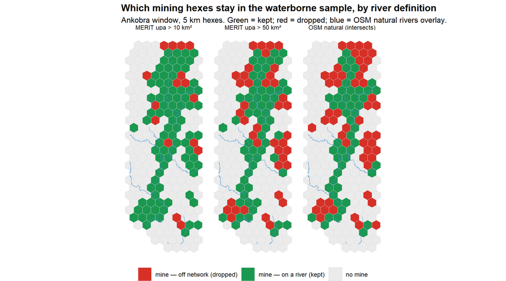

```r
# Where are the eligible vs dropped mining hexes, at the two headline MERIT thresholds AND the OSM
# natural-watercourse intersection rule (reuses osm_nat_ll / hex_win$on_osm from elig-compute)?
elig_merit <- map_dfr(thr_show, \(t) hex_win |>
  st_transform(4326) |>
  mutate(threshold = paste0("MERIT upa > ", t, " km²"),
         status = case_when(art_ha > 0 & max_upa > t ~ "mine — on a river (kept)",
                            art_ha > 0               ~ "mine — off network (dropped)",
                            TRUE                     ~ "no mine")))
elig_osm <- hex_win |>
  st_transform(4326) |>
  mutate(threshold = "OSM natural (intersects)",
         status = case_when(art_ha > 0 & on_osm ~ "mine — on a river (kept)",
                            art_ha > 0           ~ "mine — off network (dropped)",
                            TRUE                 ~ "no mine"))
elig_long <- bind_rows(elig_merit, elig_osm) |>
  mutate(threshold = factor(threshold,
                            levels = c(paste0("MERIT upa > ", thr_show, " km²"), "OSM natural (intersects)")))

ggplot(elig_long) +
  geom_sf(aes(fill = status), colour = "grey85", linewidth = 0.1) +
  geom_sf(data = osm_nat_ll, colour = "#3B8ED0", linewidth = 0.3, inherit.aes = FALSE) +
  facet_wrap(~ threshold, nrow = 1) +
  scale_fill_manual(values = c("mine — on a river (kept)"    = "#1A9850",
                               "mine — off network (dropped)" = "#D73027",
                               "no mine"                      = "grey92"), name = NULL) +
  labs(title = "Which mining hexes stay in the waterborne sample, by river definition",
       subtitle = "Ankobra window, 5 km hexes. Green = kept; red = dropped; blue = OSM natural rivers overlay.") +
  theme_void(base_size = 10) +
  theme(legend.position = "bottom", plot.title = element_text(face = "bold"))
```

In the Ankobra window, OSM direct-intersection retains only **50%** of mining hexes — *fewer* than even the coarse `upa > 50` MERIT cut (61%), let alone `upa > 10` (84%). That is consistent with the “coverage is a function of mapping effort, not hydrology” concern raised in Approach 1: MERIT’s modelled network reaches small tributaries more completely than what has actually been surveyed and drawn on OSM here. Neither definition is obviously “right” — but the gap is a reminder that “OSM says there’s no river here” and “there really is no river here” are not the same claim.

## 6.2 Ways this might be addressed — options and questions

Roughly least to most structural; we are unsure which (if any) is right:

1. **Treat the threshold as a robustness axis, not a single choice.** Estimate the effect across the whole grid of cuts. If it *strengthens* toward larger rivers, that supports the waterborne mechanism rather than being a nuisance; if flat, the dilution worry may be overstated. *Would you expect growth with river size if the mechanism is real?*
2. **A continuous flow-weighted dose instead of a binary cut.** Weight each mine’s contribution by `upa`/`wth` at the connecting reach (extends `d_04`’s existing distance-decayed exposure with a flow weight) — no hexes drop out, small streams are just down-weighted. *Is `upa` an acceptable transport-capacity proxy, or is discharge/stream power needed?*
3. **Stratify by stream order** (MERIT can yield Strahler order, `d_04` §10d) and estimate separately by size class — tests the mechanism directly. *Is Strahler order the right stratifier?*
4. **Interact treatment with a flow measure** at the low threshold — quantifies the dilution concern rather than assuming it.
5. **A physically-motivated decay/dilution kernel**, with a discharge-dependent decay length. *Does a simple model exist to parameterise for mercury vs. suspended sediment?*
6. **Separate the two roles of the threshold** — a low cut for connectivity, a flow-based dose for intensity.

### 6.2.1 Open questions for a geologist / hydrologist

- **How far does galamsey pollution actually travel, and does that depend on stream size?** Mercury sediment-bound (settles quickly) vs. dissolved/methylated (travels far) implies very different “right” thresholds.
- **Is there a physical catchment/discharge size below which a mine’s load is undetectable downstream?** That number, not a statistical convenience, should set the threshold.
- **Do turbidity/sediment and mercury have different transport lengths?** Our NDVI outcome may respond more to sediment/turbidity than to mercury.
- **Is `upa` an acceptable channel proxy at ~90 m, or should we use `wth`, modelled discharge, or stream power?**
- **Are dry- vs. wet-season flows different enough that an annual “is this a river” label is meaningless for parts of the network?**

# 7 Approach 3 — remotely sensed surface water

A third notion of “river” is *observed surface water* — pixels that actually hold water: our own **MNDWI** from Landsat/Sentinel-2 (`rs01`/`rs02`, with NDTI flagging turbid mining ponds), or **JRC Global Surface Water** (`JRC/GSW1_4/GlobalSurfaceWater`, 1984–2021, 30 m). Neither is downloaded yet; template only (needs GEE auth, not evaluated on knit):

```r
library(rgee)
bb  <- st_bbox(merit_ext_ll)
aoi <- ee$Geometry$Rectangle(c(bb[["xmin"]], bb[["ymin"]], bb[["xmax"]], bb[["ymax"]]))
occurrence <- ee$Image("JRC/GSW1_4/GlobalSurfaceWater")$select("occurrence")$clip(aoi)
mndwi <- ee$ImageCollection("COPERNICUS/S2_SR_HARMONIZED")$
  filterBounds(aoi)$filterDate("2023-11-01", "2024-03-01")$
  filter(ee$Filter$lt("CLOUDY_PIXEL_PERCENTAGE", 40))$median()$
  normalizedDifference(c("B3", "B11"))$rename("mndwi")$clip(aoi)
```

This sees *actual* water including mining ponds, but no connected channel graph, no flow direction, and is seasonal/cloud-limited. Best as a **complement** (validating MERIT channels, flagging ponds), not as the network definition.

# 8 Does the definition move `dist_river_km`?

On the 5 km hexes inside the Ankobra window, how much does distance-to-nearest-river shift across definitions? (Mirrors `d_03_waterways.R` §5–7, restricted to the MERIT extent.)

```r
cent    <- st_centroid(hex_sf)
inside  <- lengths(st_intersects(cent, merit_ext_utm)) > 0
hex_in  <- cent[inside, ]

# osm_nat_ll / osm_nat_utm already built in elig-compute
chan_pts <- function(thr) {
  m <- ifel(upa_r > thr, 1L, NA)
  suppressWarnings(as.points(m) |> st_as_sf() |> st_transform(UTM30N))
}
merit10 <- chan_pts(10); merit50 <- chan_pts(50)
wth_pts <- suppressWarnings(as.points(ifel(wth_r > 0, 1L, NA)) |> st_as_sf() |> st_transform(UTM30N))

dist_to <- function(pts, tgt) {
  idx <- st_nearest_feature(pts, tgt)
  as.numeric(st_distance(pts, tgt[idx, ], by_element = TRUE)) / 1000
}
dcmp <- tibble(
  hex_id         = hex_sf$hex_id[inside],
  `OSM natural`  = dist_to(hex_in, osm_nat_utm),
  `MERIT upa>50` = dist_to(hex_in, merit50),
  `MERIT upa>10` = dist_to(hex_in, merit10),
  `MERIT wth>0`  = dist_to(hex_in, wth_pts)
)
dcmp |>
  pivot_longer(-hex_id, names_to = "definition", values_to = "dist_km") |>
  group_by(definition) |>
  summarise(mean = round(mean(dist_km), 2), median = round(median(dist_km), 2), .groups = "drop") |>
  knitr::kable(caption = "Per-hex distance to nearest river (km) by definition — Ankobra window.")
```

Per-hex distance to nearest river (km) by definition — Ankobra window.

| definition | mean | median |
| --- | --- | --- |
| MERIT upa>10 | 1.38 | 1.19 |
| MERIT upa>50 | 3.03 | 2.66 |
| MERIT wth>0 | 7.36 | 6.59 |
| OSM natural | 4.73 | 3.78 |

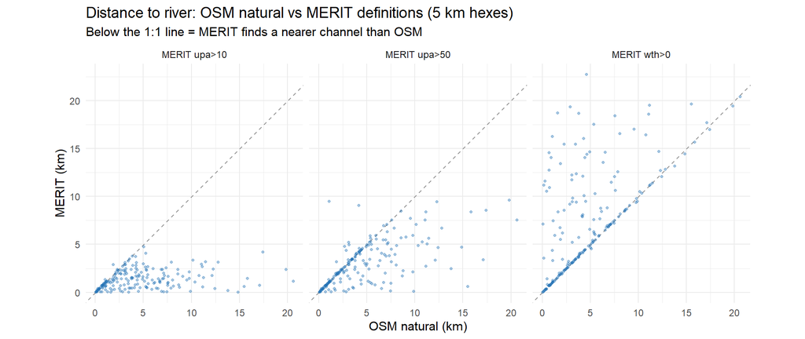

```r
dcmp |>
  pivot_longer(c(`MERIT upa>50`, `MERIT upa>10`, `MERIT wth>0`),
               names_to = "merit_def", values_to = "merit_km") |>
  ggplot(aes(`OSM natural`, merit_km)) +
  geom_abline(slope = 1, intercept = 0, colour = "grey60", linetype = 2) +
  geom_point(alpha = 0.4, size = 0.7, colour = "#2171B5") +
  facet_wrap(~ merit_def) + coord_equal() +
  labs(title = "Distance to river: OSM natural vs MERIT definitions (5 km hexes)",
       subtitle = "Below the 1:1 line = MERIT finds a nearer channel than OSM",
       x = "OSM natural (km)", y = "MERIT (km)") +
  theme_minimal(base_size = 10)
```

The denser `upa > 10` network places almost every hex close to a channel; `wth` / `upa > 50` behave more like OSM natural rivers. Which is “better” depends on use and on the mechanism questions above.

# 9 A related question: are any of these variables valid instruments?

This document has been about **defining** rivers. A separate part of the project asks a **causal** question that reuses some of the same hydro-geomorphic reasoning: since mine location is *chosen* by miners (endogenous), how do we identify mining’s actual effect on downstream outcomes, rather than just the correlation between “risky terrain” and “bad outcomes”? The standard answer is an **instrument** — a variable that predicts mining for reasons unrelated to the outcome except through mining itself. We list our current candidates here because a geologist reviewing this document is well placed to judge them, and because they are built from layers already discussed above (MERIT Hydro) plus the depositional indices in `d_06_gold_deposits.R`.

**What an instrument needs.** Two conditions: **(1) relevance** — it must actually predict where mining happens; **(2) exclusion** — it must affect the outcome (e.g. crop yields, vegetation) *only* through mining, never directly. Since galamsey is **alluvial** mining, geomorphology that predicts *where eroded gold physically settles* is the natural candidate: it is fixed by nature, long predates any economic decision, and (in principle) is not itself a driver of, say, farm productivity.

**The five candidates currently on the table:**

- **Gold-suitable geology** (Girard) — bedrock geologically predisposed to host gold at all; the broadest, coarsest candidate (1:10M).
- **HAND** (Height Above Nearest Drainage, from MERIT Hydro’s `elv`) — low HAND = active floodplains and terraces, where fast water slows and heavy eroded particles (gold is ~19× denser than water) drop out. Built in `d_06_gold_deposits.R` Sec D.
- **MRVBF** (valley-bottom flatness, from MERIT-DEM via SAGA) — flags broad flat valley floors, natural long-run sediment traps. `d_06_gold_deposits.R` Sec E.
- **Stream Power Index** $=\ln(\text{catchment area}\times\tan\text{slope})$ — proxies the energy available to move sediment; low SPI *on* a channel means the flow can no longer carry its load, so it drops what it’s carrying there. `d_04_merit.R` Sec 10a (currently disabled — heavy at full-study-area scale).
- **Stream Transport Index** — the same transport-capacity logic from slope × upslope area, a complementary formulation. `d_04_merit.R` Sec 10b.

**Are these actually meaningful instruments for gold mining, though?** We would value your view on:

- **Relevance for *artisanal* mining specifically.** HAND/MRVBF/SPI/STI describe alluvial deposition. Does that make them better predictors of galamsey (which follows surface placers) than of industrial mining (which may target deep hard-rock ore instead)? If so, does the first-stage fit actually differ by mine type in the data — is that testable?
- **Exclusion.** Valley bottoms and floodplains are also the most fertile farmland — the very thing our downstream outcome (NDVI / agricultural productivity) responds to. Does using a depositional variable as an instrument risk violating exclusion *by construction*, not just by bad luck?
- **Are the five candidates really independent?** Or are they all, at bottom, just proxies for “low, flat, wet terrain” — in which case having five of them buys little extra identifying variation over having just one?
- **Resolution mismatch.** Girard geology is 1:10M; HAND/MRVBF/SPI/STI are ~90 m (MERIT) or finer (SAGA on the DEM). Is combining something that coarse with something that fine in one first stage defensible, or does it mostly just add noise?

None of this is settled — these are candidates we are testing, not instruments we are relying on.

# 10 Where we have landed — provisionally

| Use | Leaning | Why — and our uncertainty |
| --- | --- | --- |
| **Flow graph / upstream treatment** | MERIT `dir` + a **low** `upa` cut (10 km²) | Only source with flow direction; low cut keeps small-tributary mines in the graph — but whether they should carry treatment *weight* is exactly the trade-off. |
| **`dist_river_km` covariate** | MERIT `upa > 50` or OSM natural (they agree) | Reproduces the observed river network; robustness = swap between them. |
| **Pollution-source / pond validation** | Remote sensing (MNDWI, JRC) | Sees real standing water incl. galamsey ponds — a complement, not the network. |

The part we are **least** sure about is the treatment-definition trade-off: pick a threshold, sweep it, weight by flow, or stratify by stream size? Our instinct leans toward a **continuous flow-weighted dose** (option 2/4 above) — but that rests on `upa`/`wth` being an acceptable proxy for how far galamsey pollution actually travels, which is a question for someone who knows the geochemistry. **Feedback on the open questions would change what we build next.**

*Data: MERIT Hydro (Yamazaki et al. 2019); OpenStreetMap contributors; Barenblitt et al. (2021). Companion scripts: `d_03_waterways.R` (OSM), `d_04_merit.R` (MERIT flow graph, Secs 11a–11j), `d_05_ndvi.R` (Ankobra basin definition). See also `4_presentation/methodology_explainer.md` (event-study designs).*